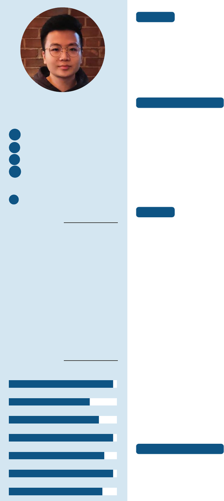

教育背景

2018-2020 硕士 乔治城大学 华盛顿特区，美国

专业: 数学统计与数据科学

GPA: 3.7/4

曾担任本专业机器学习助教; 曾担任数学辅导员

2014-2018 学士 中国农业大学 北京，中国

专业: 数学与应用数学

GPA: 3.6/4

曾担任本专业概率统计助教; 曾获得校级三等奖学金

项目经历 & 个人博客

2019 年 5 月 深度学习算法在谷歌公司股价预测上的应用

2020 年 1 月 卷积神经网络在图像识别上的应用

2020 年 4 月 基于 XGBo ost 算法的驾驶员的安全性风险分析与预测

2020 年 6 月 关于 COVID-19 (新冠病毒) 的数据分析、挖掘、可视化以及短期预测

2020 年 7 月 基于深度学习算法的癌症患者 30 天再入院率分析与预测

2020 年 3 月至今

• 你好，Julia

• 逻辑回归中的数学 vs. 编程

• 机器学习算法整理、面经以及应用

• TensorFlow 2.0 中的人工神经网络在数字识别上的应用

• 卷积神经网络在人脸识别上的应用

工作经历

• 主要工作: 参与对公司的股价预测系统在 XGBoost 模型上的改

进，并独立完成不同模型之间的评估对比工作。

• 数据预处理: 使用 Python 从万德数据库调用金融数据，并用 SQL

对数据进行转换，清洗和筛选。对数据做归一化、标准化。

• 数据可视化: 对影响目标公司股价和股息分配的排名前十的特

征用 Tableau 做气泡图以及概率分布图进行可视化，并且使用

Seaborn 以及 plotly 对数据排名前五的特征做散点回归统计图。

• 数据建模: 利用 XGRegressor、ANN 等机器学习算法对公司股

价、股息分配进行回归并预测，测试集的预测准确率达到 0.87，

并且趋势拟合基本与原数据一致，且有不错的泛化能力。

• 模型评估: 成功预测接下来的半个月股息变化趋势并在测试集上

2017-2018 上海中融汇信期货有限公司 量化研究实习生

• 主要工作: 参与构建深度神经网络模型来预测客户的违约情况以

及破产预测，并独立完成神经网络的数据预处理和参数调节工作。

• 数据预处理: 使用 Python 调取本公司的客户数据并进行缺失值

填充、特征分析、数据清洗。使用 SQL 对 50000+ 观测数的客户

数据进行分组、筛选、数据库连接整合以及数据透视转换。

• 数据建模: 构建逻辑回归、支持向量机以及随机森林等传统机器

学习算法模型对数据建模以供和深度学习算法来进行对比。

• 模型评估: 对模型的表现进行评估，深度神经网络在测试集上的

分类误差减小到 0.09, 分类准确度达到 0.89、AUC 达到 0.92、敏

感度和特异度都达到 0.83，帮助公司减少了 150000+ 人民币的

来自客户违约风险的损失。

技能资格 & 个人爱好

• 语言能力: CET-6，托福总分 103，GRE 总分 323

• 资格证书: 证券、期货从业资格证

• 个人爱好: 演讲、篮球、书法、电子科技

高子敬

数据科学工程师

i 1996 年 8 月 8 日

B 浦东新区，上海市，中国

T 18616531215

m 1. 个人网站

2. 领英

3. Github

@ gzj18616531215@outlook.com

自我评价

三年以上数据整合、清洗、转换以及分

析经验

五年以上 Python、R 以及 SQL 编程

经验

三年以上机器学习、深度学习框架搭

建、模型评估以及云计算经验

曾参与深度学习框架在股价预测和破产

分析领域中的建模和调参工作；主要负

责百万级数据量的人脸识别系统模型构

建和评估工作。

我理解的数据科学就是洞察人性的过

程，数据只不过是把用户的需求，用量

化的方式表达出来。

专业能力

思维、表达以及沟通能力

编程语言（Python、R、MATLAB）

深度学习框架（TensorFlow、PyTorch）

机器学习算法（SVM、XGBo ost 等）

关系数据库（MySQL、PostgreSQL）

云计算（Spark、Hadoop）

数据可视化（Tableau、Seaborn）

[figure not shown]

Zijing Gao

Thorough and meticulous data science enthusiast passionate with the innovative and dedicated work style

gzjgzj12345@gmail.com 2028483817 zg104.github.io linkedin.com/in/zg104 github.com/zg104

EDUCATION

08/2018 – Present

Mathematics & Statistics Master Degree

Georgetown University | Washington, D.C.

GPA: 3.7/4

Stochastical Simulation Data Mining in R

Machine Learning & Deep

Learning in TF 2.0

Data Visualization in

Tableau

08/2014 – 06/2018

Applied Mathematics Bachelor Degree

China Algricultural University | Beijing, China

GPA: 3.6/4

Probability and Statistics Numerical methods

Financial Mathematics Statistical Computing

WORK EXPERIENCE

01/2018 – 08/2018

Data Mining Intern

Atomus Asset Management Co. Ltd

SHANGHAI, CHINA

engaged in investment management and asset management business in

the ﬁeld of quantitative transactions and big data, artiﬁcial intelligence.

Provided expertise in data storage, data cleaning, and data

mining with massive ﬁnancial data (1 million + observations)

Performed strategic trading analysis by analyzing statistical

ﬁgures with Tableau, matplotlib, and seaborn

Participated in constructing a stock price prediction system

using XGBoost and LSTM by performing feature engineering to

select top 30 features to improve the training score by 5%

Tuned hyperparameters, conducted auxiliary functions, and

tested model validity to help the company's CTA strategy win

the 3rd price in one of the biggest Shanghai quantitative

trading contest (BigQuant)

02/2017 – 09/2017

Quantitative Research Intern

Zhong Rong Hui Xin Futures Co. Ltd

SHANGHAI, CHINA

Committed to developing into a professional provider of futures derivatives

with core competitiveness in trading investment and risk management.

Utilized visualization tools (Tableau, matplotlib, ggplot2,

Seaborn) for data intelligence and analysis

Participated in the construction of deep neural networks with

multiple hidden layers to predict default probability over

50,000+ customers

Improved the eﬃciency and speed of deep learning algorithms

by 40% with Apache Spark and BigQuery in GCP

Improved the classiﬁcation accuracy by 9.1% through feature

engineering and parameter tuning to help the company shrink

the loss from customer default by 20,000+ USD

SKILLS

Mathematics (Calculus, Algebra) & Statistics

Programming languages (Python, R, java, MATLAB)

Machine & Deep Learning Platform (PyTorch, TensorFlow)

Relational databases (PostgreSQL, MySQL)

Data Visualization (Tableau, Seaborn, matplotlib, ggplot2)

Cloud Computing (Spark, Hadoop, GCP, AWS)

PERSONAL PROJECTS

Google Stock Price Prediction in Deep Learning

(08/2019 – 11/2019)

My proposed model is signiﬁcantly better than the other machine

learning models, with an adjusted R2 average of 0.95

Glass Indentiﬁcation in Criminal Analysis

(01/2020 – 04/2020)

Constructed diﬀerent machine learning methods to identify the glass

type in the crime scene to help crack criminals

Ensemble tree methods perform better than other machine learning

methods with identiﬁcation error: 8.7%, AUC: 95.4%, and cross-

entropy: 0.09

Animal Image Recognition in Deep Learning

(03/2020 – 05/2020)

Constructed the TensorFlow structure to establish a multiple hidden-

layers convolutional neural network (CNN) for animal image

identiﬁcation

Improved the classiﬁcation accuracy up to 91.2% with validation loss

to be 6.2% after parameter tuning

Porto Seguro’s Safe Driver Prediction in XGBoost

(06/2020 – Present)

Conducted data preparation and data explorartory analysis

Constructed a model that predicts the probability that a driver will

initiate an auto insurance claim in the next year

Normalized Gini coeﬃcient is around 0.284 (0.5 is perfect) after 5-fold

CV and parameter tuning

GEORGETOWN UNIVERSITY

Graduate School of Arts & Sciences

(05/2019 – 05/2020)

Math (probablity, calculus, algebra) Tutor; Teaching Assistant in Machine

Learning

[figure not shown]

Zijing Gao

Phone: 2028483817 | Email: zg104@georgetown.edu | Linkedin: linkedin.com/in/zg104 | Github: github.com/zg104 | Portfolio: zg104.github.io

EDUCATION

College of Art and Science, Georgetown University Aug 2018 – May 2020

Washington, D.C, USA

Master of Science in Mathematics and Statistics GPA: 3.7 /4.0

Relevant Coursework: Time Series Analysis, Stochastic Simulation, Cloud Computing, Deep Learning

College of Science, China Agricultural University Aug 2014 – May 2018

Beijing, China

Bachelor of Science in Mathematics and Applied Mathematics GPA: 3.6/4.0

EXPERIENCE

• Atomus Asset Management Co. Ltd Shanghai, China

Data Analyst Intern 01/2018 - 08/2018

o Provided expertise in data storage, data cleaning, and data mining with 1 million + observations

o Performed strategic trading analysis with visualization tools like Tableau, matplotlib, and seaborn

o Participated in constructing a stock price prediction system using XGBoost and LSTM by

performing feature engineering to select top 30 features to improve the training score by 5%

o Tuned hyperparameters, conducted GBDT + LR for feature selection, and tested model validity to

help the company's CTA strategy win 3rd place in the BigQuant quantitative trading contest

• Zhong Rong Hui Xin Futures Co. Ltd Shanghai, China

Quantitative Researcher Intern 02/2017 – 09/2017

o Utilized visualization tools (Tableau, ggplot2, Seaborn) for data intelligence and analysis

o Participated in the construction of deep neural networks with multiple hidden layers to predict

default probability over 50,000+ customers

o Improved the efficiency and speed of deep learning algorithms by 40% with Apache Spark and

conducted data flow analysis using BigQuery in GCP

o Increased the classification accuracy by 9.1% through feature engineering and parameter tuning

to help the company shrink the loss from customer default by 20,000+ USD

PROJECTS

• Google Stock Price Prediction in Deep Learning 08/2019 – 11/2019

o Utilized an attention-based LSTM neural network to predict the stock adjusted closing price

o Reached the adjusted R2 average of 0.95 by overcoming long sequential dependency challenges

with global max pooling, dropout and other parameter tuning techniques

• Glass Identification in Criminal Analysis 01/2020 – 04/2020

o Constructed different machine learning methods to identify the glass type in the crime scene

o Ensemble tree methods perform better than other machine learning methods with identification

error: 8.7%, AUC: 95.4%, and cross- entropy: 0.09

• Animal Image Recognition in Deep Learning 03/2020 – 05/2020

o Built the TensorFlow structure to establish a multiple hidden-layer convolutional neural network

(CNN) for animal image identification

o Improved the classification accuracy up to 91.2% with validation loss to be 6.2% after 5-fold CV

• Porto Seguro’s Safe Driver Prediction in XGBoost 06/2020 – Present

o Conducted data preparation, data quality check, feature engineering, feature selection and EDA

o Developed a model that predicts if a driver will initiate an auto insurance claim in the next year

o Normalized Gini coefficient is around 0.284 (0.5 is perfect) after 5-fold CV and parameter tuning

SKILLS

• Programming Languages & Relational Databases: Python, R, MATLAB; PostgreSQL, MySQL

• Data Tools: AWS, GCP, PySpark, Hadoop, Excel, TensorFlow, PyTorch

• Visualization Techniques: Tableau, ggplot2, Seaborn, Matplotlib, plotly